# Medidas de tendencia central. 1° Actividad

[Axel Matadamas Bernal](https://axelmbernal.github.io)

Estadística 2022-2, [Facultad de economía](http://www.economia.unam.mx/)

2/3/2022

### ¿Qué son las medidas de tendencia central?

### Definición:

“parámetro de tendencia central o medida de centralización es un número ubicado hacia el centro de la distribución de los valores de una serie de observaciones (medidas), en la que se encuentra ubicado el conjunto de los datos. Las medidas de tendencia central más utilizadas son: media, mediana y moda”.

[Wikipedia(2022)](https://es.wikipedia.org/wiki/Medidas_de_tendencia_central)

Para este ejemplo, primero generaremos una serie de **100** números aleatorios entre **1** y **20** mediante la función `sample`. El argumento `TRUE` nos permitirá generar una muestra con remplazo:

```r
numeros <- sample(1:20, 100, TRUE)
numeros
```

```
##   [1] 13 10 12 16 20 12  2 20  6  8 13  2  4 18 20 19  2 10 17  6  4 13  9 11 20
##  [26]  1  6  1 16  3  4  6  3 10  7 13 12  2  3  4  5  1 17  2  5  6  9  4 11  8
##  [51]  7 15 19  6  8  5  6 11  5 10 15 14 11 17 12 15 10  6  7 14  4  5 11 19  4
##  [76] 15  5  3  7 15  4 10 20 20 12 12  9  9 11  3  4 20 20  5 15  4 17 16  4 18
```

### Mediana 📍

> Definición:

Representa el valor de la variable de posición central en un conjunto de datos ordenados. Si la serie tiene un número par de puntuaciones, la mediana es la media entre las dos puntuaciones centrales.

Wikipedia(2022)

Para obtener la **mediana**, podemos ordenar los `numeros` de menor a mayor, **el número que esté en medio de la muestra será la mediana**. Si utilizamos R, se puede hacer el cálculo de la **mediana** con la función `median`:

```r
mediana <- median(numeros)
mediana
```

```
## [1] 9.5
```

### Media 🧮

> Definición:

Se obtiene a partir de la suma de todos sus valores dividida entre el número total de sumandos.

[Wikipedia(2022)](https://es.wikipedia.org/wiki/Media_aritm%C3%A9tica)

$$Media ={\frac {1}{n}}\sum _{i=1}^{n}a_{i}={\frac {a_{1}+a_{2}+\cdots +a_{n}}{n}}$$

Si usamos R, podemos obtener la media de una muestra si utlilizamos la función **mean**:

```r
media <- mean(numeros)
media
```

```
## [1] 9.8
```

### Moda 📊

> Definición:

La moda es el valor que aparece con mayor frecuencia en un conjunto de datos. Esto va en forma de una columna cuando encontremos dos modas, es decir, dos datos que tengan la misma frecuencia absoluta máxima. Una distribución trimodal de los datos es en la que encontramos tres modas.

Wikipedia(2022)

Podemos saber cuál es la **frecuencia** (número de veces que aparece un elemento en una muestra) de cada número si dibujamos un **histograma** con la función `hist`, **aquel elemento con mayor frecuencia será la moda**:

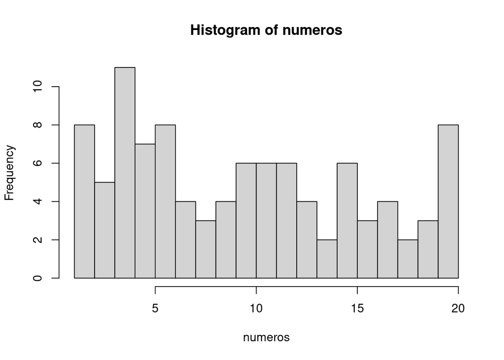

```r
# El argumento breaks nos permite dividir en histograma en las partes que queramos
hist(numeros, breaks = 20)
```

Para obtener un resultado con más precisión, podemos obtener la **moda** si generamos una **tabla de frecuencias** con la función `table` y la función `data.frame`, **aquel elemento con mayor frecuencia será la moda**:

```r
tabla.frecuencias <- data.frame(table(numeros))
tabla.frecuencias
```

```
##    numeros Freq
## 1        1    3
## 2        2    5
## 3        3    5
## 4        4   11
## 5        5    7
## 6        6    8
## 7        7    4
## 8        8    3
## 9        9    4
## 10      10    6
## 11      11    6
## 12      12    6
## 13      13    4
## 14      14    2
## 15      15    6
## 16      16    3
## 17      17    4
## 18      18    2
## 19      19    3
## 20      20    8
```

### 5. Ejercicio 👩‍💻👨‍💻✍

Aplica lo que aprendiste, obten la **mediana**, **media** y **moda** de la siguiente muestra de números:

```r
# Con la función seq, creamos una secuencia de 1 a 10 en intervalos de 0.1 en 0.1
secuencia <- seq(1, 10, 0.1)
muestra <- sample(secuencia, 100, TRUE)
muestra
```

```
##   [1]  5.8  6.5  5.9  7.8  6.5  4.1  7.0  9.1  7.1  2.9  5.1  7.6 10.0  6.7  9.5
##  [16]  7.0  5.8  6.6  2.8  9.1  2.3  5.8  6.5  5.6  1.8  5.1  9.5  2.9  1.2  5.2
##  [31]  8.9  6.9  4.9  9.1  7.9  4.4  4.2  4.5  8.7  2.1  5.0  4.7  5.0  1.3  3.6
##  [46]  6.9  4.1  7.6  8.0  7.9  7.4  1.2  8.5  3.5  8.8  1.3  3.0  7.4  2.0  4.8
##  [61]  9.6  7.4  1.2  1.6  6.9  1.5  6.6  6.3  1.0  3.9  2.3  6.6  1.3  6.6  8.6
##  [76]  2.0  3.3  3.2  8.5  8.0  8.1  2.6  8.6  5.4  2.9  5.0  2.5  6.4  5.2  4.4
##  [91]  6.0  8.0  9.2  7.8  1.6  9.6  5.0  2.5  2.3  5.7
```

##### Mediana

```r
# Ahora hay que calcular la mediana
meddiana<-median(muestra)
meddiana
```

```
## [1] 5.75
```

##### Media

```r
# Lo siguiente es la Media
Meddia<-mean(muestra)
Meddia
```

```
## [1] 5.476
```

##### Moda

```r
# Y por último la moda
tabla.muestra <- data.frame(table(muestra))
tabla.muestra
```

```
##    muestra Freq
## 1        1    1
## 2      1.2    3
## 3      1.3    3
## 4      1.5    1
## 5      1.6    2
## 6      1.8    1
## 7        2    2
## 8      2.1    1
## 9      2.3    3
## 10     2.5    2
## 11     2.6    1
## 12     2.8    1
## 13     2.9    3
## 14       3    1
```

[output cut: 45 more lines]